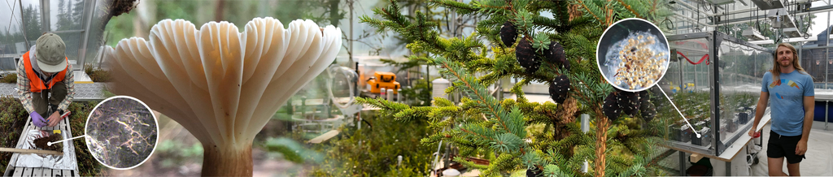

# Biography

I am currently a postdoctoral researcher with Eddie Brzostek at West Virginia University (WVU), funded by the [US DOE’s CABBI](https://cabbi.bio/), where I investigate the sustainability of *Miscanthus × giganteus* as a biofuel using FUN-BioCROP. I am currently incorporating multiple depths into FUN-BioCROP to better evaluate how the deep rooting profile of *M. × giganteus* impacts soil C sequestration. I am directing the investigation into the relationship between AMF biomass and *M. × giganteus* yield, nutrient uptake, and soil C sequestration in plots established by collaborators in the [Morrissey Lab at WVU](https://morrisseyem.wixsite.com/morrisseywvu).

Previously I researched the responses of fine roots among different plant functional types to warming and elevated CO<sub>2</sub> in the [SPRUCE experiment](https://mnspruce.ornl.gov/) as a postdoctoral researcher with Colleen Iversen at Oak Ridge National Laboratory, funded by the [US DOE’s TES-SFA project](https://tes-sfa.ornl.gov/). Working as an empiricist on the same team as modelers convinced me of the power and importance of coupling well-designed empirical studies to process-based models at the ecosystem and earth system scale.

For my doctorate I used radio-isotopes to examine the exchange of plant-C and AMF-P in tightly controlled greenhouse experiments testing the responses of resource exchange to a gradient of AMF species richness, plant choice among AMF species, and AMF choice among plant species with Pascal Niklaus at the University of Zürich. This work was supported by the [Zürich-Basel Plant Science Center](https://www.plantsciences.uzh.ch/en.html). During this time I also co-supervised my student Lea Buol for her [masters thesis](https://www.zora.uzh.ch/id/eprint/231598/1/2022_Buol_LeaSophie.pdf).

Before my doctoral studies, I acted as the laboratory manager and technician for Marko Spasojevic at the University of California Riverside (UCR). The majority of my time was spent at [Niwot Ridge LTER](https://nwt.lternet.edu/) measuring plant functional traits, coordinating field campaigns, and mentoring an undergraduate for her summer NSF-REU project.

Prior to working with Marko, I did my masters at UCR with Jeffrey Diez and Michael Allen studying the responses of AMF to multiple global change drivers in the coastal sage scrub of the [Loma Ridge Global Change Experiment](https://lomaridge.bio.uci.edu/).

My B.S. in Biology was received from the University of Central Florida, where I pursued research projects in plant-soil feedbacks, AMF, soil CO<sub>2</sub> respiration, and population genetics.